# Effect of Intravenous Fat Emulsions on Outcomes in Critically Ill Patients

## 0.1 Preliminaries

```r
library(skimr)
library(rms)
library(tidyverse)
```

# 1 Task 1: Data Source

These data come from the critical care database maintained in the adult surgical intensive care unit (SICU) at Vanderbilt University, and provided by Chris Slaughter, DrPH, at Vanderbilt University’s Department of Biostatistics.

A complete explanation of the dataset is available on their website including a link to the raw data, called IVFE dataset. The data is a retrospective review of patients admitted from 2001 to 2005 and had a stay in the SICU of three or more days.

URL: http://biostat.mc.vanderbilt.edu/wiki/Main/CourseBios312

## 1.1 Explanation of the study from Vanderbilt Biostatistics wiki

Excerpted from: http://biostat.mc.vanderbilt.edu/wiki/pub/Main/CourseBios312/ivfe-project-description-2013.pdf

This data is part of the critical care database maintained in the adult SICU. The objective of the study is to determine if IVFE has an adverse effect on outcomes in critically ill patients.

IVFE are used in parenteral nutrition to provide a source of energy as an alternative to dextrose as well as provide essential fatty acids. IVFE are an energy-dense source of calories compared with proteins and dextrose. It is generally recommended in clinical practice that lipids should provide 15% to 30% of total calories or 30 to 50% of non-protein calories.

Wanten GJA, Calder PC, (2007) Immune modulation by parenteral lipid emulsions. AM J Clin Nutr 85, 1171-84.

# 2 Task 2: Load and Tidy the Data

```r
# Loading the data
IVFE <- read.csv("IVFE.csv") %>% tbl_df

# Creating a multi-categorical BMI
IVFE.data <- IVFE %>%
  rename(subj = X) %>%
  mutate(subj=as.character(subj)) %>%
  mutate(apache2=as.numeric(apache2), glucose=as.numeric(glucose)) %>%
  mutate(bmi_cat = case_when(
    bmi < 18.5 ~ "Underweight",
    bmi < 25 ~ "Normal",
    bmi < 30 ~ "Overweight",
    bmi >= 30 ~ "Obese")) %>%
  mutate(bmi_cat = fct_reorder( bmi_cat, bmi, median ))

# Filtering BMI data to reasonable range
IVFE.data <- IVFE.data %>%
  filter(bmi > 10 & bmi < 80)

# Mutating to factors
IVFE.data <- IVFE.data %>%
  mutate(bsi.inf = factor(bsi.inf, levels = 0:1, labels = c("No", "Yes")),
         pneu.inf = factor(pneu.inf, levels = 0:1, labels = c("No", "Yes")),
         hosp.death = factor(hosp.death, levels = 0:1, labels = c("No", "Yes")),
         lipids = factor(lipids, levels = 0:1, labels = c("No", "Yes")))

# set.seed to get the same random sample
set.seed(44106)

# of 1,000 subjects from the dataset
# Selecting the required variables
IVFE.data <- sample_n(IVFE.data, size = 1000) %>%
  select(subj, age, gender, bmi, bmi_cat, hosp.los,
                      hosp.death, apache2, bsi.inf,pneu.inf, glucose,lipids)
```

After loading the csv file, I created a multi-categorical variable using BMI data. The bmi_cat was divided into underweight, normal, overweight and obese category using the cut-offs from the Centers for Disease Control. To keep the BMI within acceptable range - I filtered values from 10-80.

The subject column numbers were mutated as a ‘character’ and the infection data and mortality as a factor. After setting a seed, I also selected a sample of 1000 subjects for this study.

Finally, I selected the required variables for the study.

# 3 Task 3: Listing of My Tibble

```r
IVFE.data
```

```
# A tibble: 1,000 x 12
   subj    age gender   bmi bmi_cat    hosp.los hosp.death apache2 bsi.inf
   <chr> <dbl> <fct>  <dbl> <fct>         <dbl> <fct>        <dbl> <fct>
 1 414    17.9 F       26.9 Overweight     9.59 No             15. No
 2 1749   57.5 M       24.5 Normal        13.1  No             21. No
 3 1371   42.8 M       24.7 Normal        10.0  No             10. No
 4 412    59.1 F       27.1 Overweight    28.1  No             16. No
 5 594    81.4 M       25.7 Overweight    15.5  Yes            17. No
 6 1706   48.4 F       72.1 Obese         23.4  No             11. No
 7 588    56.0 M       33.9 Obese         28.2  No             19. No
 8 1817   40.5 F       47.5 Obese         18.2  No             14. No
 9 636    54.4 M       27.7 Overweight     6.87 No             19. No
10 1423   35.5 M       26.0 Overweight     7.92 No             29. No
# ... with 990 more rows, and 3 more variables: pneu.inf <fct>,
#   glucose <dbl>, lipids <fct>
```

```r
glimpse(IVFE.data)
```

```
Observations: 1,000
Variables: 12
$ subj       <chr> "414", "1749", "1371", "412", "594", "1706", "588",...
$ age        <dbl> 17.91, 57.51, 42.83, 59.06, 81.37, 48.37, 56.00, 40...
$ gender     <fct> F, M, M, F, M, F, M, F, M, M, F, M, M, M, F, F, M, ...
$ bmi        <dbl> 26.93, 24.47, 24.69, 27.13, 25.70, 72.06, 33.92, 47...
$ bmi_cat    <fct> Overweight, Normal, Normal, Overweight, Overweight,...
$ hosp.los   <dbl> 9.5924, 13.0653, 10.0396, 28.0910, 15.5347, 23.4049...
$ hosp.death <fct> No, No, No, No, Yes, No, No, No, No, No, No, No, No...
$ apache2    <dbl> 15, 21, 10, 16, 17, 11, 19, 14, 19, 29, 11, 12, 19,...
$ bsi.inf    <fct> No, No, No, No, No, No, No, No, No, No, No, No, No,...
$ pneu.inf   <fct> No, No, No, No, No, No, No, No, No, No, No, No, No,...
$ glucose    <dbl> 137, 106, 300, 243, 145, 173, 153, 111, 257, 250, 2...
$ lipids     <fct> No, No, Yes, No, Yes, No, No, No, No, No, No, No, N...
```

```r
skim_with(numeric = list(hist = NULL), integer = list(hist = NULL))

skim(IVFE.data)
```

```
Skim summary statistics
 n obs: 1000
 n variables: 12

Variable type: character
 variable missing complete    n min max empty n_unique
     subj       0     1000 1000   1   4     0     1000

Variable type: factor
   variable missing complete    n n_unique
    bmi_cat       0     1000 1000        4
    bsi.inf       0     1000 1000        2
     gender       0     1000 1000        2
 hosp.death       0     1000 1000        2
     lipids       0     1000 1000        2
   pneu.inf       0     1000 1000        2
                            top_counts ordered
 Obe: 326, Nor: 319, Ove: 303, Und: 52   FALSE
               No: 971, Yes: 29, NA: 0   FALSE
                 M: 608, F: 392, NA: 0   FALSE
               No: 915, Yes: 85, NA: 0   FALSE
              No: 714, Yes: 286, NA: 0   FALSE
               No: 926, Yes: 74, NA: 0   FALSE

Variable type: numeric
 variable missing complete    n   mean    sd    p0    p25 median    p75
      age       0     1000 1000  57.73 15.42 17.71  48.45  58.36  68.82
  apache2       0     1000 1000  17.71  6.31  2     13     17     22
      bmi       0     1000 1000  28.67  8.65 10.73  23.09  26.66  32.19
  glucose       0     1000 1000 185.18 68.17 36    141    171.5  215
 hosp.los       0     1000 1000  15.97 13.42  3      7.92  11.77  19.35
   p100
  98.64
  41
  77.85
 523
 137.66
```

Our tibble IVFE.data contains 1000 rows (patients) and 12 columns (variables). Each variable is contained in a column, and each row represents a single subject. All variables now have appropriate types.

# 4 Task 4: Code Book

[output not shown]

# 5 Task 5: My Subjects

The data describes a sample of 1000 patients admitted from 2001 to 2005, who had a stay in the SICU of three or more days.

# 6 Task 6: My Variables

1. subj: IVFE identification code
2. age: Age in years
3. gender: Gender, M = male, F = female
4. bmi: Body mass index (weight divided by height squared)
5. bmi_cat: bmi categories - Underweight, Normal, Overweight, Obese
6. hosp.los: Hospital length of stay
7. hosp.death: Indicator of death in the hospital (1=died, 0=survive)
8. apache2: Apache 2 score at admission; a disease severity score
9. bsi.inf: bloodstream infection (1=infection, 0=no infection)
10. pneu.inf: Pneumonia (1=infection, 0=no infection)
11. glucose: Blood glucose level at admission
12. lipids: Received intravenous lipids during first 3 days of their SICU stay (1=yes, 0=no)

# 7 Task 7: My Planned Linear Regression Model

Predictors: * age * gender * bmi_cat (multi-categorical) * glucose * lipids * Apache2 score * blood stream infection * pneumonia * hospital death

# 8 Task 8: My Planned Logistic Regression Model

Predictors: * age * gender * bmi_cat (multi-categorical) * glucose * lipids * Apache2 score * blood stream infection * pneumonia * hospital length of stay

# 9 Task 9: Affirmation

This data set meets all requirements specified in the project instructions.

There are no missing values in the dataset.

We are considering at least four predictors for each regression model, and we include at least one quantitative and multi-categorical variable in each model.

I (Abhishek Deshpande) am certain that it is completely appropriate for these data to be shared with anyone, without any conditions. There are no concerns about privacy or security, mostly because the data have been on a public website for many years, and are completely free of identifying information about individual subjects. There are no concerns about privacy or security.

# 10 Task 10: Linear Regression

Develop training and test samples

```r
set.seed(44106)

IVFE.data_training <- IVFE.data %>% sample_frac(.70)

IVFE.data_test <- anti_join(IVFE.data, IVFE.data_training, by = "subj")

dim(IVFE.data)
```

```
[1] 1000   12
```

```r
dim(IVFE.data_training); dim(IVFE.data_test)
```

```
[1] 700  12
```

```
[1] 300  12
```

Spearman Plot

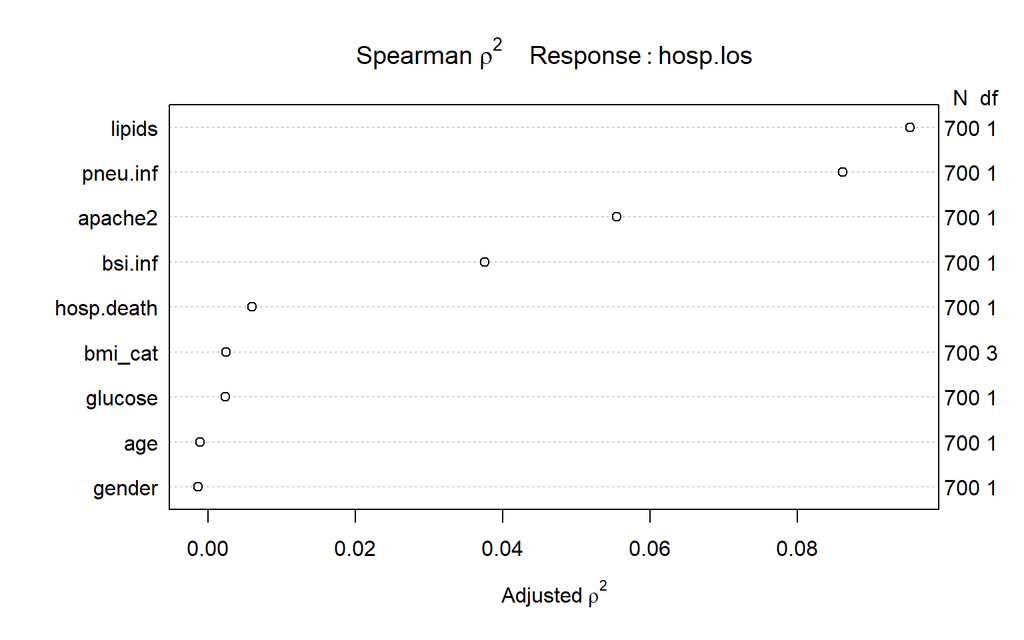

```r
plot(Hmisc::spearman2(hosp.los ~ age + gender + bmi_cat + glucose + lipids + apache2 + bsi.inf + pneu.inf + hosp.death, data = IVFE.data_training))
```

Model A using `ols`

```r
d <- datadist(IVFE.data_training)
options(datadist = "d")

ModA <- ols(hosp.los ~ age + gender + bmi_cat + glucose + lipids +
              apache2 + bsi.inf + pneu.inf + hosp.death,
            data = IVFE.data_training, x = TRUE, y = TRUE)
ModA
```

```
Linear Regression Model

 ols(formula = hosp.los ~ age + gender + bmi_cat + glucose + lipids +
     apache2 + bsi.inf + pneu.inf + hosp.death, data = IVFE.data_training,
     x = TRUE, y = TRUE)

                 Model Likelihood     Discrimination
                    Ratio Test           Indexes
 Obs      700    LR chi2    121.49    R2       0.159
 sigma12.5656    d.f.           11    R2 adj   0.146
 d.f.     688    Pr(> chi2) 0.0000    g        5.468

 Residuals

     Min      1Q  Median      3Q     Max
 -22.516  -6.514  -3.185   3.612 110.637


                    Coef    S.E.   t     Pr(>|t|)
 Intercept          12.7353 3.2509  3.92 <0.0001
 age                -0.0915 0.0331 -2.76 0.0059
 gender=M           -1.3696 0.9989 -1.37 0.1708
 bmi_cat=Normal     -0.0298 2.2480 -0.01 0.9894
 bmi_cat=Overweight  2.1091 2.2558  0.93 0.3501
 bmi_cat=Obese       0.2855 2.2329  0.13 0.8983
 glucose            -0.0007 0.0074 -0.10 0.9214
 lipids=Yes          3.2752 1.0937  2.99 0.0028
 apache2             0.3806 0.0808  4.71 <0.0001
 bsi.inf=Yes         6.7965 2.7220  2.50 0.0128
 pneu.inf=Yes       13.3821 1.9229  6.96 <0.0001
 hosp.death=Yes      0.3492 1.7274  0.20 0.8398
```

Confidence Interval

```r
confint(ModA, level = 0.90)
```

```
                          5 %        95 %
Intercept           7.3808223 18.08978040
age                -0.1460422 -0.03692218
gender=M           -3.0149392  0.27565709
bmi_cat=Normal     -3.7323168  3.67275647
bmi_cat=Overweight -1.6063189  5.82454390
bmi_cat=Obese      -3.3921964  3.96320578
glucose            -0.0128441  0.01139166
lipids=Yes          1.4739081  5.07657820
apache2             0.2476005  0.51367717
bsi.inf=Yes         2.3131501 11.27980185
pneu.inf=Yes       10.2150033 16.54921491
hosp.death=Yes     -2.4958566  3.19434170
```

ABHISHEK DESHPANDE

2018-03-08 00:15:54